# DV 3 demo

Published

September 28, 2023

```r
library(tidyverse)
library(ggthemes)              # additional ggplot themes
library(ggrepel)               # for additional plot labeling
theme_set(theme_pander())      # set your default theme for this session
```

## An orienting example

```r
library(gapminder)
data(gapminder)
```

We’ll just keep the most recent data in this dataset (2007).

```r
gm2007 <- gapminder |>
  filter(year == 2007)
```

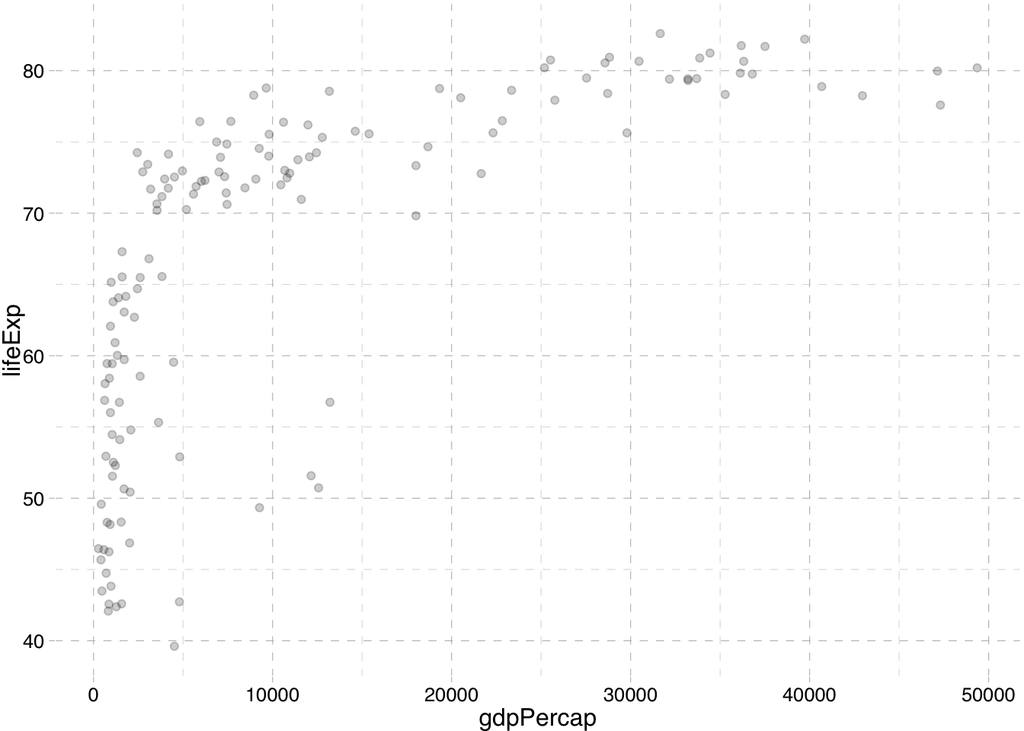

```r
ggplot(gm2007,
            aes(x = gdpPercap,
                y = lifeExp)) +
  geom_point(alpha = .2)
```

What is the correlation? Why might correlation not be the best number to work with here?

```r
gm2007 |>
  select(gdpPercap, lifeExp) |>
  cor()
```

```
          gdpPercap   lifeExp
gdpPercap 1.0000000 0.6786624
lifeExp   0.6786624 1.0000000
```

## What **is** correlation?

Let’s start with a few ideas.

### mean

The mean is the most common measure of the “average” value.

$$\bar{x} = \frac{\sum x_i}{n}$$
Let’s check the mean value of life expectancy in these data.

```r
mean(gm2007$lifeExp)
```

```
[1] 67.00742
```

### standard deviation

The **standard deviation** is a measure of how spread out the data are.

$$SD_x = \sqrt{\frac{\sum (x_i - \bar{x})^2}{n-1}}$$
First let’s look at this visually.

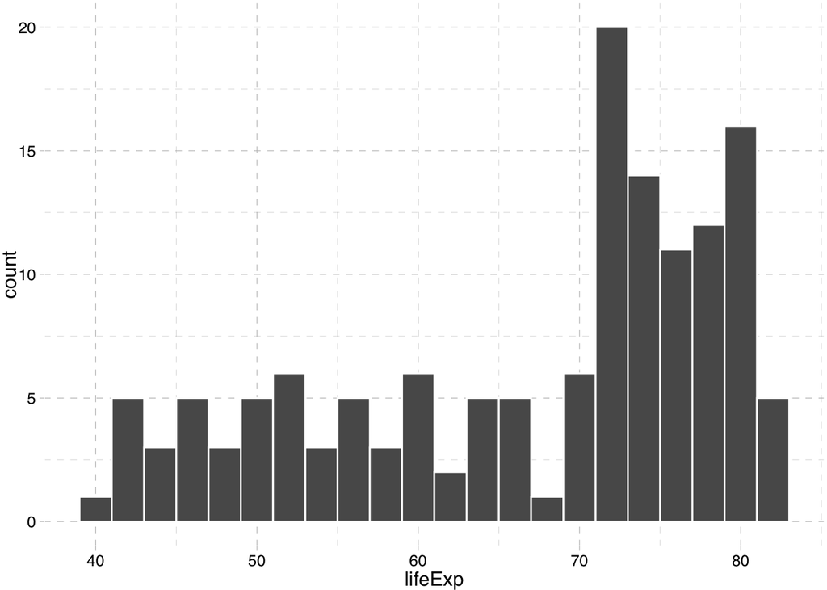

```r
ggplot(gm2007,
       aes(x = lifeExp)) +
  geom_histogram(binwidth = 2,
                 color = "white")
```

ASIDE: if you’re looking to get a good baseline for breaks, try this.

```r
breaks <- pretty(
  gm2007$lifeExp,                   # give it the variable
  nclass.Sturges(gm2007$lifeExp))   # ask "Sturges" to tell you how many bins

breaks
```

```
 [1] 35 40 45 50 55 60 65 70 75 80 85
```

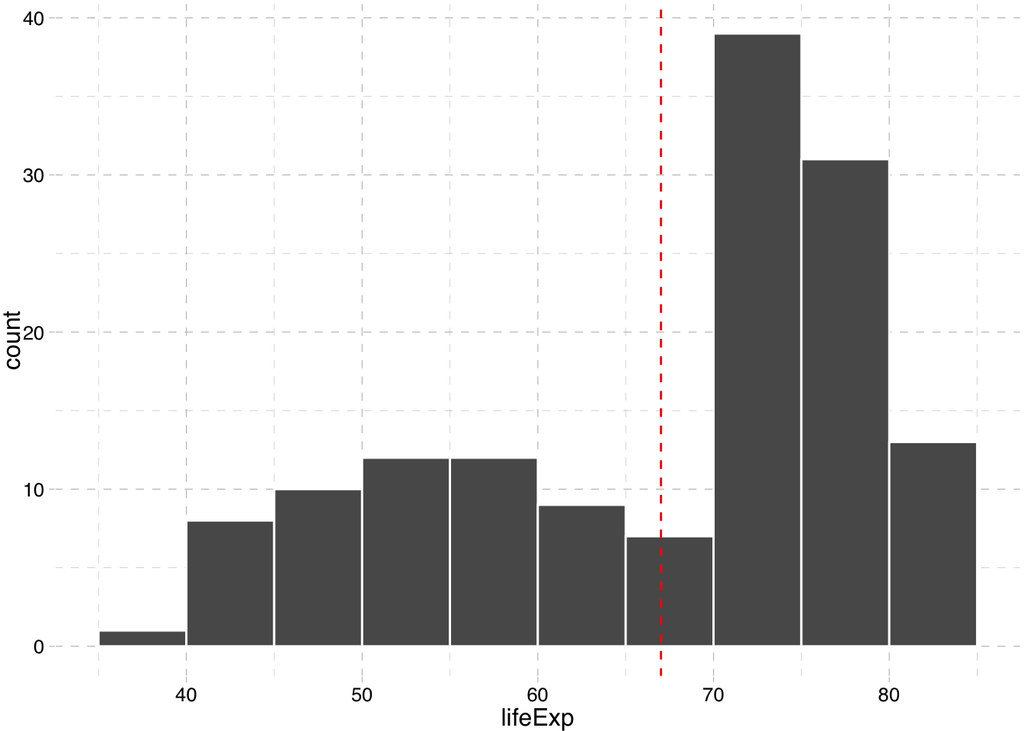

```r
ggplot(gm2007,
       aes(x = lifeExp)) +
  geom_histogram(breaks = breaks,
                 color = "white") +
  geom_vline(xintercept = mean(gm2007$lifeExp),
             color = "red",
             linetype = "dashed")
```

What is the standard deviation here?

```r
sd(gm2007$lifeExp)
```

```
[1] 12.07302
```

**The “empirical” rule**: if you can’t visualize the data for some reason, it’s a reasonable approximation to estimate that 68% of the data lie within 1 SD of the mean and 95% lie within 2 SDs of the mean. This works better the more “bell shaped” (i.e., “normal”) your data are. So it probably wouldn’t work great here!

### standardized variable

Variables are measured in units like dollars or years. If we want a “unitless” measure of something, we can *standardize* a variable. Let’s call that variable $x^*$.

$$x^*_i = \frac{x_i-\bar{x}}{SD_x}$$
The unit now is “how many standard deviations from the mean is this observation”?

### correlation

To calculate the correlation between two variables, we need both variables standardized. Then apply this formula:

$$r_{xy} = \frac{\sum x^*_i y^*_i}{n}$$
The idea here is when one variable is 1 standard deviation higher, the other variable will be $r_{xy}$ standard deviations higher.

Let’s check this out.

```r
# get means and SDs
mean_gdp <- mean(gm2007$gdpPercap)
sd_gdp <- sd(gm2007$gdpPercap)
mean_lexp <- mean(gm2007$lifeExp)
sd_lexp <- sd(gm2007$lifeExp)

# make new standardized variables
gm2007 <- gm2007 |>
  mutate(z_gdp = (gdpPercap - mean_gdp) / sd_gdp,
         z_lexp = (lifeExp - mean_lexp) / sd_lexp)
```

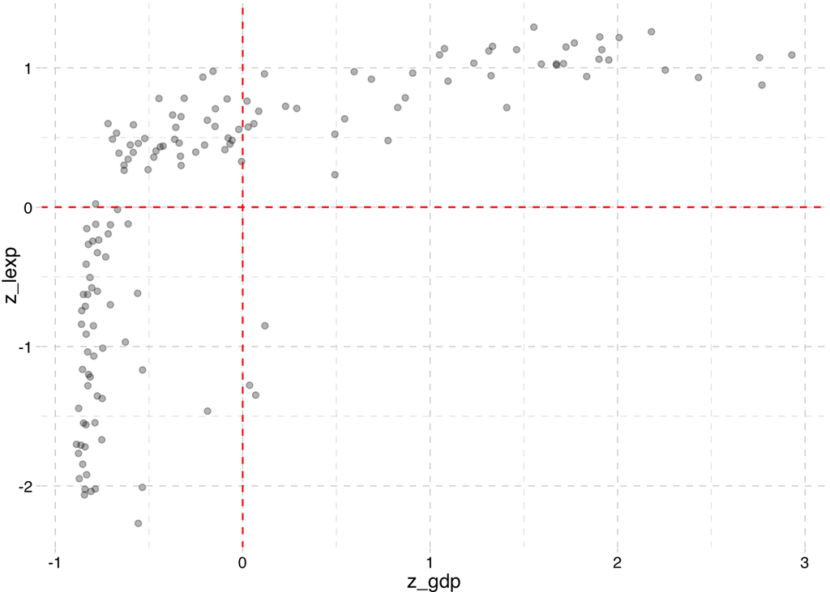

```r
ggplot(gm2007,
       aes(x = z_gdp,
           y = z_lexp)) +
  geom_point(alpha = .3) +
  geom_vline(xintercept = 0,
             linetype = "dashed",
             color = "red") +
  geom_hline(yintercept = 0,
             linetype = "dashed",
             color = "red")
```

Points in the bottom left and top right quadrants will increase the correlation value; points in the other quadrants will decrease it.

### a note on the problem

Correlation is based on the idea of *linear* relationships. This relationship isn’t very linear, perhaps due to the diminishing returns of the economy to life expectancy.

What if we used the base 2 log of GDP instead?

```r
gm2007 <- gm2007 |>
  mutate(log2gdp = log2(gdpPercap))
```

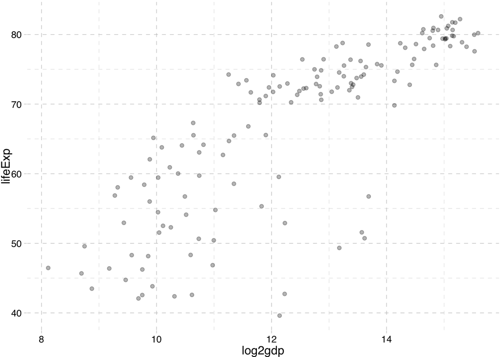

```r
ggplot(gm2007,
       aes(x = log2gdp,
           y = lifeExp)) +
  geom_point(alpha = .3)
```

```r
gm2007 <- gm2007 |>
  mutate(log10gdp = log10(gdpPercap))
```

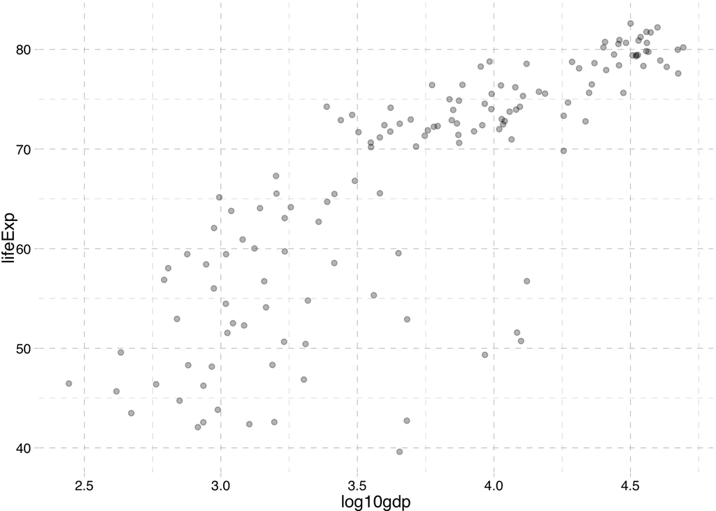

```r
ggplot(gm2007,
       aes(x = log10gdp,
           y = lifeExp)) +
  geom_point(alpha = .3)
```

```r
gm2007 |>
  select(log2gdp,
         lifeExp) |>
  cor()
```

```
          log2gdp   lifeExp
log2gdp 1.0000000 0.8089803
lifeExp 0.8089803 1.0000000
```

## Why we plot

```r
data(anscombe)
anscombe
```

```
   x1 x2 x3 x4    y1   y2    y3    y4
1  10 10 10  8  8.04 9.14  7.46  6.58
2   8  8  8  8  6.95 8.14  6.77  5.76
3  13 13 13  8  7.58 8.74 12.74  7.71
4   9  9  9  8  8.81 8.77  7.11  8.84
5  11 11 11  8  8.33 9.26  7.81  8.47
6  14 14 14  8  9.96 8.10  8.84  7.04
7   6  6  6  8  7.24 6.13  6.08  5.25
8   4  4  4 19  4.26 3.10  5.39 12.50
9  12 12 12  8 10.84 9.13  8.15  5.56
10  7  7  7  8  4.82 7.26  6.42  7.91
11  5  5  5  8  5.68 4.74  5.73  6.89
```

Since we’re using dplyr, let’s get this long rather than wide.

```r
anscombe_long <- anscombe %>%
  pivot_longer(
    everything(),
    names_to = c(".value", "set"),
    names_pattern = "(.)(.)"
  ) |>
  arrange(set)

anscombe_long
```

```
# A tibble: 44 × 3
   set       x     y
   <chr> <dbl> <dbl>
 1 1        10  8.04
 2 1         8  6.95
 3 1        13  7.58
 4 1         9  8.81
 5 1        11  8.33
 6 1        14  9.96
 7 1         6  7.24
 8 1         4  4.26
 9 1        12 10.8
10 1         7  4.82
# ℹ 34 more rows
```

Now let’s compute the mean and SD for each set of X and Y.

```r
anscombe_long |>
  group_by(set) |>
  summarize(
    across(.cols = c(x, y),
           .fns = list(mean = mean, sd = sd),
           .names = "{col}_{fn}"))
```

```
# A tibble: 4 × 5
  set   x_mean  x_sd y_mean  y_sd
  <chr>  <dbl> <dbl>  <dbl> <dbl>
1 1          9  3.32   7.50  2.03
2 2          9  3.32   7.50  2.03
3 3          9  3.32   7.5   2.03
4 4          9  3.32   7.50  2.03
```

They look the same, but these sorts of numbers can be deceiving!

Now let’s plot the scatter plots of each of the four sets.

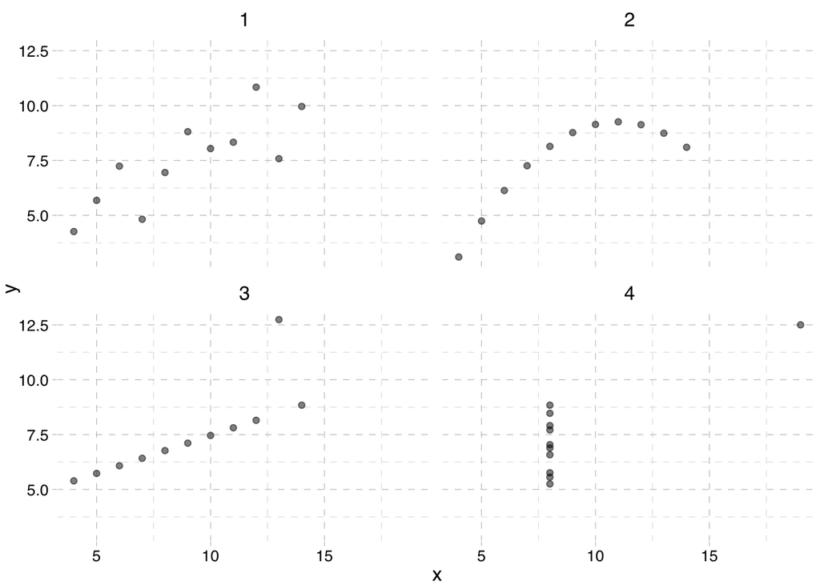

```r
ggplot(anscombe_long,
       aes(x = x,
           y = y)) +
  geom_point(alpha = .5) +
  facet_wrap(~set)
```

Without looking at the data, this would be **very** hard to notice!

## A football (soccer) example

```r
library(worldfootballR)
d <- fb_match_results(country = "ENG",
                      gender = "M",
                      season_end_year = 2022)
```

How well does xG track with actual goals?

Again, we don’t want HomeGoals/AwayGoals and Home_xG and Away_xG in different columns. We don’t care about game results here, so let’s get a structure where all the goals are in one column and all the xgs are in another.

```r
d2 <- d |>
  mutate(matchid = 1:nrow(d)) |>
  select(matchid, Home, Away, HomeGoals, AwayGoals, Home_xG, Away_xG) |>
  rename(team1 = Home,
         team2 = Away,
         xg1 = Home_xG,
         xg2 = Away_xG,
         goals1 = HomeGoals,
         goals2 = AwayGoals) |>
  pivot_longer(
    cols = c(-matchid),
    names_pattern = "(.+)([12])",
    names_to = c(".value", "home_away"),
    values_to = c("team", "goals", "xg"))
```

What’s the correlation between xG and goals?

```r
cor(d2$goals,
    d2$xg)
```

```
[1] 0.6735144
```

Plot it!

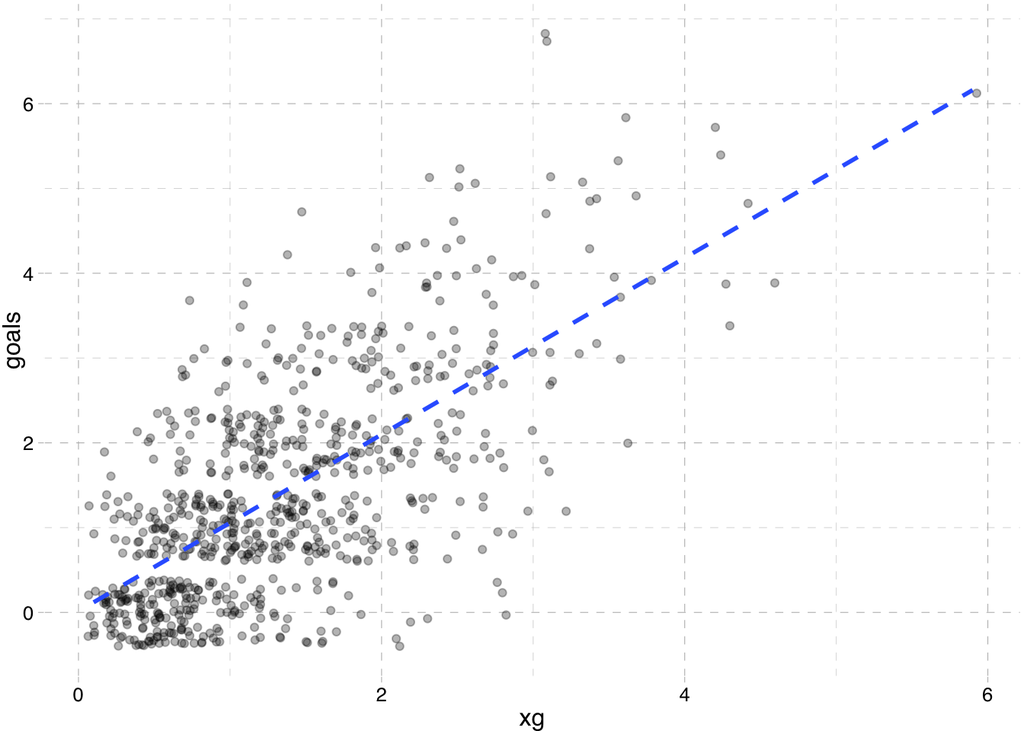

```r
ggplot(d2,
       aes(x = xg,
           y = goals)) +
  geom_jitter(alpha = .3) +
  geom_smooth(method = "lm",
              se = FALSE,
              linetype = "dashed")
```